# Reporting d’une analyse multivariée

Cohorte 1955 - Agriculteurs ayant débuté leur carrière entre 1945 et 1965

Morade Ayofe OSENI - Abdou Khadre DABO - Diele-eunice DIAVOU-DIAVOU

04/04/2026

# Introduction

Les agriculteurs constituent une population professionnelle exposée, tout au long de leur carrière, à une multitude de facteurs environnementaux et chimiques potentiellement néfastes pour la santé : pesticides, poussières organiques et inorganiques, agents biologiques (virus zoonotiques, champignons), radiations ultraviolettes, gaz d’échappement diesel et solvants. Ces expositions sont susceptibles d’engendrer diverses pathologies, notamment des affections respiratoires - asthme, bronchite chronique, emphysème, rhume des foins, maladie du poumon de fermier - mais aussi des maladies cardiovasculaires, métaboliques ou neurodégénératives (Omland, 2002 ; Hernandez *et al.*, 2013).

Le métier d’agriculteur se caractérise en outre par une **multi-activité** souvent simultanée : élevage bovin, cultures céréalières, viticulture, maraîchage peuvent se pratiquer conjointement sur une même exploitation, générant des profils d’exposition complexes et cumulatifs. Or, les études épidémiologiques classiques examinent généralement une seule activité ou nuisance à la fois, ignorant la nature combinée de ces expositions (Blair *et al.*, 2005).

Pour dépasser cette limite, la cohorte **AGRICAN** (AGRIculture et CANcer) a été constituée afin d’étudier les liens entre les pratiques agricoles et la survenue de maladies chez les affiliés de la Mutualité Sociale Agricole. Dans ce cadre, les **méthodes factorielles et de classification non supervisée** - Analyse en Composantes Principales (ACP) et clustering (CAH, K-means, K-médoïdes, Fuzzy-C-means, DBSCAN) - permettent de regrouper les individus selon leurs profils d’exposition globaux reconstitués sur l’ensemble de leur carrière, puis d’analyser la prévalence des maladies au sein de chaque groupe ainsi formé (Leon *et al.*, 2011).

Le présent rapport s’inscrit dans la SAE *Reporting d’une analyse multivariée* du BUT Science des Données (IUT Grand Ouest Normandie - antenne de Lisieux). Il porte sur la **cohorte 1955**, soit les agriculteurs masculins de la cohorte AGRICAN ayant débuté leur carrière entre 1945 et 1965 (N = 11 934 individus analysés).

# 1 Description de la population et des variables

## 1.1 La cohorte AGRICAN

La cohorte AGRICAN est une cohorte prospective portant sur les affiliés MSA (Mutualité Sociale Agricole) résidant dans l’un des 11 départements français couverts par un registre de cancers. Les participants ont été recrutés entre novembre 2005 et décembre 2007.

**Critères d’inclusion de la cohorte AGRICAN :**

- Affilié(e) à la MSA
- Âgé(e) d’au moins 18 ans au 1<sup>er</sup> janvier 2004
- Résidant dans l’un des 11 départements couverts par un registre de cancers
- Affilié(e) depuis au moins 3 ans, avec plus de 12 trimestres de cotisation validés

**Critères d’exclusion ayant conduit à la population d’étude finale (N = 29 794) :**

Tableau 1 - Flux d’inclusion/exclusion de la population d’étude

| Étape | Effectif |
| --- | --- |
| Population initiale AGRICAN | 181 842 |
| Exclusion des femmes | −83 048 |
| Exclusion du département Côte-d’Or (sans registre général) | −6 186 |
| Exclusion des hommes non classifiables comme agriculteurs | −9 833 |
| Exclusion des non-agriculteurs (avec ou sans exposition) | −10 666 |
| Exclusion des agriculteurs avec données incomplètes (≥1/189 variables) | −42 315 |
| **Population d’étude finale** | **29 794** |

## 1.2 La cohorte 1955 (population de ce rapport)

La sous-cohorte **1955** regroupe les agriculteurs hommes dont la carrière agricole a débuté entre **1945 et 1965**. Cette délimitation temporelle vise à homogénéiser les profils d’exposition, les pratiques agricoles ayant significativement évolué au fil des décennies.

La **cohorte 1955** regroupe les agriculteurs masculins dont la carrière agricole a débuté entre **1945 et 1965**. Cette délimitation vise à homogénéiser les profils d’exposition : les pratiques agricoles et les niveaux d’usage des pesticides ayant fortement évolué d’une génération à l’autre, analyser une période homogène améliore la cohérence des comparaisons inter-individus.

Tableau 2 - Constitution de l’échantillon analysé (cohorte 1955)

| Étape | Effectif |
| --- | --- |
| Effectif initial de la cohorte 1955 (après exclusion durée de carrière = 0) | 12 026 |
| Lignes supprimées (ratios d’activité incohérents > 1) | − 92 |
| Effectif final analysé | 11 934 |

Les 92 individus exclus présentaient au moins un ratio d’activité supérieur à 1, signe d’une incohérence de saisie dans le questionnaire. Leur exclusion garantit la validité des variables entrant dans l’ACP.

## 1.3 Variables utilisées et construction des ratios

Le questionnaire d’inclusion AGRICAN (environ 600 variables) recense, pour chaque agriculteur, les activités exercées avec leurs périodes de pratique. Deux types de ratios ont été construits :

**Ratio d’activité :**
$$\text{Ratio}_{\text{activité}} =
\frac{\text{Année de fin} - \text{Année de début de
l'activité}}{\text{Durée totale de la carrière
agricole}}$$

**Ratio de tâche :**
$$\text{Ratio}_{\text{tâche}} = \frac{\text{Durée
de pratique de la tâche}}{\text{Durée totale de l'activité
associée}}$$

Ces ratios, compris entre 0 et 1, représentent la **proportion de la carrière** consacrée à chaque activité ou tâche. Ils constituent les variables d’entrée de l’ACP.

# 2 Exploration des données - ACP

## 2.1 Sélection des 10 cultures les plus fréquentes

L’ACP porte sur **15 variables** : les 5 ratios d’élevage et les 10 ratios de culture les plus fréquents dans la cohorte 1955. Le classement est établi par la moyenne du ratio sur l’ensemble de la population.

```r
tab_moy <- data.frame(
  Culture = names(sort(moyennes, decreasing = TRUE)),
  Moyenne = round(sort(moyennes, decreasing = TRUE), 4),
  Sélectionnée = c(rep("✔", 10), rep("✘", length(moyennes) - 10))
)
rownames(tab_moy) <- NULL

kbl(tab_moy, col.names = c("Culture (ratio)", "Moyenne du ratio", "Retenue dans l'ACP"),
    caption = "Tableau 3 - Classement des 13 cultures par fréquence (moyenne du ratio)") %>%
  kable_styling(bootstrap_options = c("striped","hover","condensed"), full_width = FALSE) %>%
  column_spec(3, color = ifelse(tab_moy$Sélectionnée == "✔", "green", "red"),
              bold = TRUE)
```

Tableau 3 - Classement des 13 cultures par fréquence (moyenne du ratio)

| Culture (ratio) | Moyenne du ratio | Retenue dans l’ACP |
| --- | --- | --- |
| Ratio_Prai | 0.5882 | ✔ |
| Ratio_Ble | 0.4759 | ✔ |
| Ratio_Vigne | 0.3072 | ✔ |
| Ratio_Mais | 0.2831 | ✔ |
| Ratio_PdT | 0.1904 | ✔ |
| Ratio_Bet | 0.1670 | ✔ |
| Ratio_Arb | 0.1128 | ✔ |
| Ratio_LegChamp | 0.0637 | ✔ |
| Ratio_Tabac | 0.0551 | ✔ |
| Ratio_Col | 0.0509 | ✔ |
| Ratio_Tou | 0.0350 | ✘ |
| Ratio_Pois | 0.0292 | ✘ |
| Ratio_Serres | 0.0256 | ✘ |

Les **10 cultures retenues** sont : Prai, Ble, Vigne, Mais, PdT, Bet, Arb, LegChamp, Tabac, Col.

## 2.2 Sélection du nombre de composantes

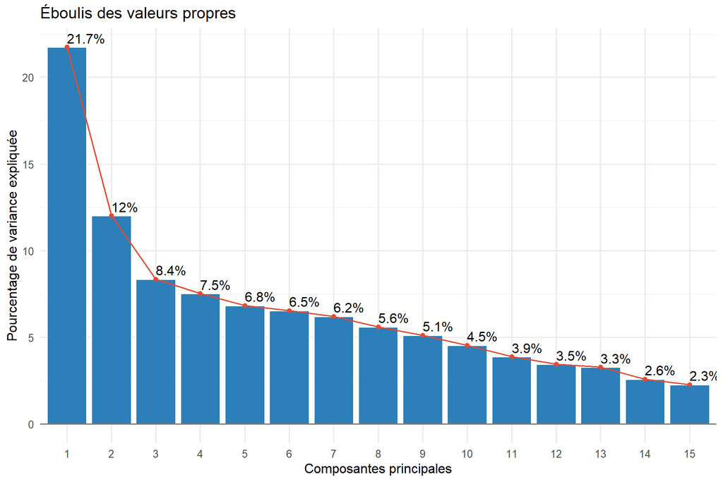

Figure 1 - Éboulis des valeurs propres (critère des 80%)

```r
fviz_eig(acp,
         addlabels = TRUE,
         ncp       = 15,
         barfill   = "#2c7fb8",
         barcolor  = "white",
         linecolor = "#e34a33") +
  labs(title = "Éboulis des valeurs propres",
       x     = "Composantes principales",
       y     = "Pourcentage de variance expliquée") +
  geom_hline(yintercept = 0, color = "grey50") +
  theme_minimal(base_size = 12)
```

```r
eig_df <- as.data.frame(acp$eig)
eig_df <- eig_df %>%
  mutate(
    `Composante`              = paste0("Dim", 1:nrow(eig_df)),
    `Valeur propre`           = round(eigenvalue, 3),
    `% Variance`              = round(`percentage of variance`, 2),
    `% Variance cumulée`      = round(`cumulative percentage of variance`, 2),
    Retenue                   = ifelse(`% Variance cumulée` <= 82, "✔", "")
  ) %>%
  select(Composante, `Valeur propre`, `% Variance`, `% Variance cumulée`, Retenue)

kbl(eig_df,
    caption = "Tableau 4 - Valeurs propres et variance expliquée (critère : 80%)") %>%
  kable_styling(bootstrap_options = c("striped","hover","condensed"), full_width = FALSE) %>%
  column_spec(5, bold = TRUE, color = "#2ca25f")
```

Tableau 4 - Valeurs propres et variance expliquée (critère : 80%)

|  | Composante | Valeur propre | % Variance | % Variance cumulée | Retenue |
| --- | --- | --- | --- | --- | --- |
| comp 1 | Dim1 | 3.260 | 21.74 | 21.74 | ✔ |
| comp 2 | Dim2 | 1.802 | 12.01 | 33.75 | ✔ |
| comp 3 | Dim3 | 1.254 | 8.36 | 42.11 | ✔ |
| comp 4 | Dim4 | 1.128 | 7.52 | 49.63 | ✔ |
| comp 5 | Dim5 | 1.026 | 6.84 | 56.47 | ✔ |
| comp 6 | Dim6 | 0.982 | 6.55 | 63.02 | ✔ |
| comp 7 | Dim7 | 0.932 | 6.22 | 69.23 | ✔ |
| comp 8 | Dim8 | 0.840 | 5.60 | 74.83 | ✔ |
| comp 9 | Dim9 | 0.769 | 5.13 | 79.96 | ✔ |
| comp 10 | Dim10 | 0.682 | 4.55 | 84.51 |  |
| comp 11 | Dim11 | 0.582 | 3.88 | 88.39 |  |
| comp 12 | Dim12 | 0.518 | 3.45 | 91.84 |  |
| comp 13 | Dim13 | 0.491 | 3.28 | 95.12 |  |
| comp 14 | Dim14 | 0.389 | 2.60 | 97.72 |  |
| comp 15 | Dim15 | 0.343 | 2.28 | 100.00 |  |

## 2.3 Description des 4 premières composantes

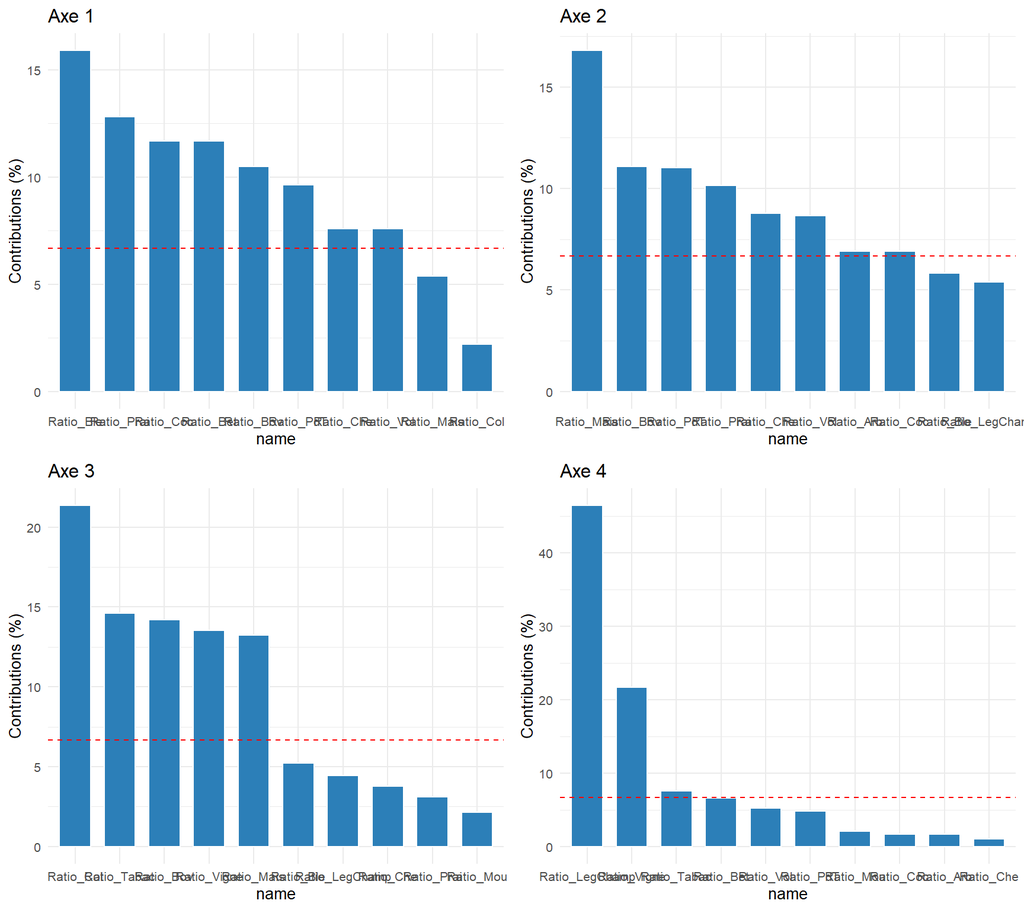

Figure 2 - Contributions des variables aux 4 premières composantes

```r
p_list <- lapply(1:4, function(i){
  fviz_contrib(acp, choice = "var", axes = i, top = 10,
               fill = "#2c7fb8", color = "white") +
    labs(title = paste0("Axe ", i)) +
    theme_minimal(base_size = 10)
})
gridExtra::grid.arrange(grobs = p_list, ncol = 2)
```

```r
cor_df <- as.data.frame(acp$var$cor)
cor_df$Variable <- rownames(cor_df)
cor_df <- cor_df %>%
  select(Variable, Dim.1, Dim.2, Dim.3, Dim.4) %>%
  mutate(across(where(is.numeric), ~ round(.x, 3)))

kbl(cor_df, row.names = FALSE,
    col.names = c("Variable","Axe 1","Axe 2","Axe 3","Axe 4"),
    caption = "Tableau 5 - Corrélations variables / composantes (4 premières dimensions)") %>%
  kable_styling(bootstrap_options = c("striped","hover","condensed"), full_width = TRUE) %>%
  column_spec(2, bold = abs(cor_df$Dim.1) >= 0.55,
              color = ifelse(abs(cor_df$Dim.1) >= 0.55, "#c0392b", "black")) %>%
  column_spec(3, bold = abs(cor_df$Dim.2) >= 0.45,
              color = ifelse(abs(cor_df$Dim.2) >= 0.45, "#c0392b", "black")) %>%
  column_spec(4, bold = abs(cor_df$Dim.3) >= 0.40,
              color = ifelse(abs(cor_df$Dim.3) >= 0.40, "#c0392b", "black")) %>%
  column_spec(5, bold = abs(cor_df$Dim.4) >= 0.45,
              color = ifelse(abs(cor_df$Dim.4) >= 0.45, "#c0392b", "black"))
```

Tableau 5 - Corrélations variables / composantes (4 premières dimensions)

| Variable | Axe 1 | Axe 2 | Axe 3 | Axe 4 |
| --- | --- | --- | --- | --- |
| Ratio_Bov | 0.585 | -0.447 | -0.422 | -0.012 |
| Ratio_Mou | 0.221 | 0.127 | -0.164 | 0.154 |
| Ratio_Coc | 0.617 | 0.353 | -0.135 | 0.138 |
| Ratio_Che | 0.498 | 0.398 | -0.217 | 0.107 |
| Ratio_Vol | 0.497 | 0.395 | -0.082 | 0.243 |
| Ratio_Prai | 0.646 | -0.427 | -0.198 | 0.042 |
| Ratio_Ble | 0.720 | -0.324 | 0.256 | -0.075 |
| Ratio_Vigne | -0.164 | 0.275 | 0.412 | 0.494 |
| Ratio_Mais | 0.419 | -0.550 | 0.407 | 0.062 |
| Ratio_PdT | 0.561 | 0.446 | 0.128 | -0.232 |
| Ratio_Bet | 0.617 | 0.199 | 0.090 | -0.273 |
| Ratio_Arb | 0.227 | 0.353 | 0.078 | 0.137 |
| Ratio_LegChamp | -0.033 | 0.311 | 0.236 | -0.724 |
| Ratio_Tabac | 0.187 | 0.020 | 0.428 | 0.292 |
| Ratio_Col | 0.267 | -0.148 | 0.518 | -0.058 |

**Interprétation des 4 premiers axes :**

**Axe 1 (21,74 % de variance)** - Cet axe est dominé par des corrélations positives fortes avec **Ratio_Ble (0.720)**, **Ratio_Prai (0.646)**, **Ratio_Coc (0.617)**, **Ratio_Bet (0.617)** et **Ratio_Bov (0.585)**. Il oppose les agriculteurs ayant consacré une grande part de leur carrière à des activités polyvalentes (céréales, prairies, élevage bovin et porcin) à ceux dont la carrière est moins diversifiée. Cet axe peut être interprété comme un **gradient d’intensité et de polyvalence agricole** : un score élevé sur cet axe traduit une pratique extensive et multiple d’activités agricoles.

**Axe 2 (12,01 % de variance)** - Cet axe est structuré par une opposition entre **Ratio_Mais (−0.550)** et **Ratio_Bov (−0.447)** d’un côté, et **Ratio_PdT (+0.446)** de l’autre. Il distingue les agriculteurs orientés vers le **maïs et l’élevage bovin** (scores négatifs) de ceux davantage tournés vers la **pomme de terre et d’autres cultures**. Cet axe reflète une spécialisation géographique et culturale typique des années 1945–1965.

**Axe 3 (8,36 % de variance)** - Les variables les plus contributrices sont **Ratio_Col (0.518)**, **Ratio_Tabac (0.428)** et **Ratio_Bov (−0.422)**. Cet axe oppose les agriculteurs pratiquant des **cultures industrielles ou spécialisées** (colza, tabac) à ceux centrés sur l’élevage bovin. Il traduit une dimension de **spécialisation vers les cultures de rente**.

**Axe 4 (7,52 % de variance)** - Cet axe est fortement structuré par **Ratio_LegChamp (−0.724)** en opposition à **Ratio_Vigne (+0.494)**. Il oppose nettement les **maraîchers** (légumes en plein champ) aux **viticulteurs**, deux profils aux pratiques et expositions aux pesticides très distinctes.

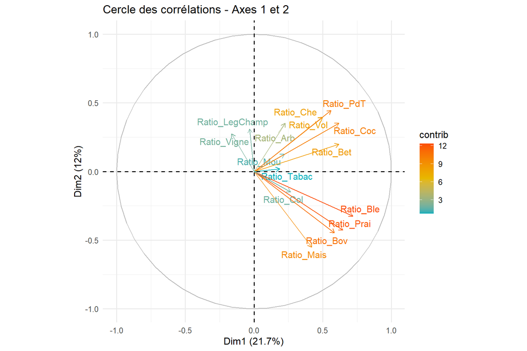

Figure 3 - Cercle des corrélations (axes 1 et 2)

```r
fviz_pca_var(acp,
             col.var    = "contrib",
             gradient.cols = c("#00AFBB", "#E7B800", "#FC4E07"),
             repel      = TRUE,
             title      = "Cercle des corrélations - Axes 1 et 2") +
  theme_minimal(base_size = 12)
```

# 3 Clustering

## 3.1 Partie I - Comparaison des méthodes de clustering

### 3.1.1 Détermination du nombre optimal de clusters

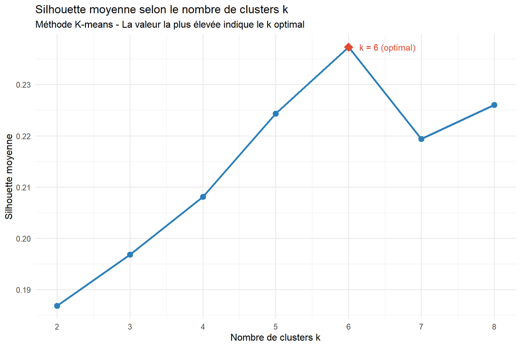

Figure 4 - Silhouette moyenne selon k (K-means, k = 2 à 8)

```r
sil_k_df <- data.frame(
  k                  = 2:8,
  Silhouette_moyenne = c(0.1868, 0.1968, 0.2081, 0.2243, 0.2373, 0.2194, 0.2260)
)

ggplot(sil_k_df, aes(x = k, y = Silhouette_moyenne)) +
  geom_line(color = "#2c7fb8", linewidth = 1.2) +
  geom_point(size = 3, color = "#2c7fb8") +
  geom_point(data = sil_k_df[sil_k_df$k == 6, ],
             aes(x = k, y = Silhouette_moyenne),
             color = "#e34a33", size = 5, shape = 18) +
  annotate("text", x = 6.15, y = 0.2373,
           label = "k = 6 (optimal)", hjust = 0, color = "#e34a33", size = 3.8) +
  scale_x_continuous(breaks = 2:8) +
  labs(title    = "Silhouette moyenne selon le nombre de clusters k",
       subtitle = "Méthode K-means - La valeur la plus élevée indique le k optimal",
       x        = "Nombre de clusters k",
       y        = "Silhouette moyenne") +
  theme_minimal(base_size = 12)
```

> La méthode de la silhouette indique **k = 6** comme nombre optimal de clusters (silhouette = 0.2373). Ce choix est retenu pour l’ensemble des méthodes de clustering.

### 3.1.2 Description des méthodes

**Classification Ascendante Hiérarchique (CAH)**  
La CAH construit un arbre de regroupements successifs (dendrogramme) à partir de la matrice de distances inter-individus. On utilise ici le critère de **Ward (ward.D2)**, qui minimise l’inertie intra-classe à chaque fusion. Le nombre de clusters est déterminé en “coupant” le dendrogramme à hauteur k = 6.

**K-means**  
L’algorithme K-means affecte chaque individu au centre (centroïde) le plus proche, puis recalcule les centroïdes itérativement. Paramètres utilisés : `centers = k`, `nstart = 25` (pour éviter les optima locaux). Initialisation aléatoire fixée par `set.seed(123)`.

**K-médoïdes (PAM)**  
Similaire au K-means, mais les centres de clusters sont des individus réels (médoïdes), ce qui le rend plus robuste aux valeurs aberrantes. Implémenté via la fonction `pam()` du package `cluster`.

**Fuzzy-C-means**  
Contrairement aux méthodes dures (chaque individu appartient à un seul cluster), le fuzzy clustering affecte à chaque individu un **degré d’appartenance** à chacun des k clusters. Le paramètre de flou `m = 2` contrôle la douceur des frontières. L’appartenance finale est déterminée par le cluster de plus haut degré.

**DBSCAN (Density-Based Spatial Clustering)** DBSCAN regroupe les points dans des zones de haute densité locale, sans imposer un nombre de clusters prédéfini. Paramètres : `eps = 1` (rayon de voisinage), `minPts = 5`. Les points isolés sont marqués comme *bruit* (cluster 0). Dans notre jeu de données, DBSCAN a identifié **58 micro-clusters** avec 2 714 points classés comme bruit (22,7 % des individus), témoignant d’une distribution des données peu adaptée à cette méthode.

### 3.1.3 Comparaison par silhouette moyenne

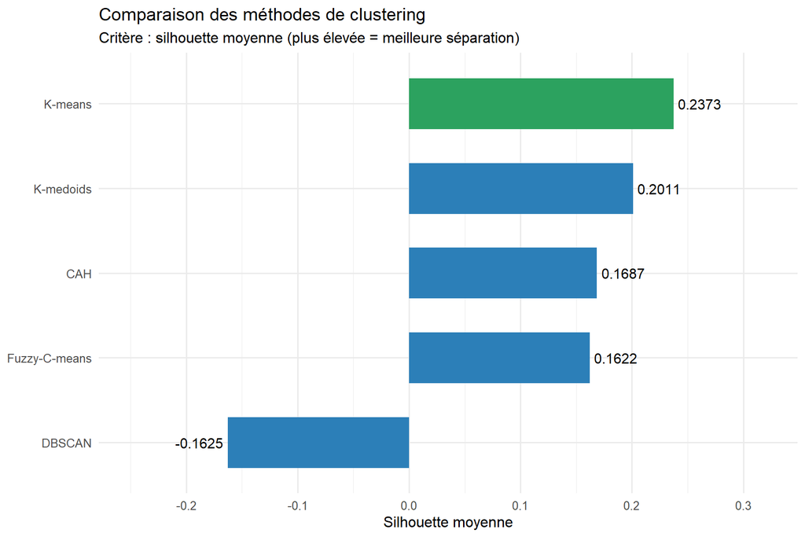

Figure 5 - Silhouette moyenne par méthode de clustering

```r
results_plot <- data.frame(
  Methode    = c("CAH","K-means","K-medoids","Fuzzy-C-means","DBSCAN"),
  Silhouette = c(0.1687, 0.2373, 0.2011, 0.1622, -0.1625)
)

ggplot(results_plot,
       aes(x = reorder(Methode, Silhouette), y = Silhouette,
           fill = Methode == "K-means")) +
  geom_col(width = 0.6, show.legend = FALSE) +
  geom_text(aes(label = round(Silhouette, 4),
                hjust = ifelse(Silhouette >= 0, -0.1, 1.1)),
            size = 4) +
  scale_fill_manual(values = c("TRUE" = "#2ca25f", "FALSE" = "#2c7fb8")) +
  coord_flip() +
  labs(title    = "Comparaison des méthodes de clustering",
       subtitle = "Critère : silhouette moyenne (plus élevée = meilleure séparation)",
       x = NULL, y = "Silhouette moyenne") +
  theme_minimal(base_size = 12) +
  scale_y_continuous(limits = c(-0.25, 0.32))
```

```r
results_display <- data.frame(
  Methode    = c("CAH","K-means","K-medoids","Fuzzy-C-means","DBSCAN"),
  Silhouette = c(0.1687, 0.2373, 0.2011, 0.1622, -0.1625),
  Selection  = c("", "★ Retenue", "", "", "")
)

kbl(results_display,
    col.names = c("Méthode", "Silhouette moyenne", "Sélection"),
    caption   = "Tableau 6 - Comparaison des méthodes de clustering par silhouette moyenne",
    align     = c("l","c","c")) %>%
  kable_styling(bootstrap_options = c("striped","hover","condensed"), full_width = FALSE) %>%
  row_spec(2, bold = TRUE, background = "#d4edda")
```

Tableau 6 - Comparaison des méthodes de clustering par silhouette moyenne

| Méthode | Silhouette moyenne | Sélection |
| --- | --- | --- |
| CAH | 0.1687 |  |
| K-means | 0.2373 | ★ Retenue |
| K-medoids | 0.2011 |  |
| Fuzzy-C-means | 0.1622 |  |
| DBSCAN | -0.1625 |  |

> **Méthode retenue : K-means** (silhouette moyenne = 0.2373). Le DBSCAN obtient une silhouette négative (−0.1625) en raison de sa fragmentation en 58 micro-clusters inadaptée à la structure des données.

### 3.1.4 Analyse des 4 plus gros clusters - vue d’ensemble

```r
clust_sizes <- sort(table(data$cluster), decreasing = TRUE)
tab_sizes   <- data.frame(
  Cluster  = names(clust_sizes),
  Effectif = as.integer(clust_sizes),
  `%`      = round(as.numeric(clust_sizes) / sum(clust_sizes) * 100, 2)
)

kbl(tab_sizes, col.names = c("Cluster", "Effectif", "% de la population"),
    caption = "Tableau 7 - Taille des clusters") %>%
  kable_styling(bootstrap_options = c("striped","hover","condensed"), full_width = FALSE)
```

Tableau 7 - Taille des clusters

| Cluster | Effectif | % de la population |
| --- | --- | --- |
| 2 | 4633 | 38.82 |
| 3 | 3842 | 32.19 |
| 6 | 1621 | 13.58 |
| 1 | 636 | 5.33 |
| 5 | 626 | 5.25 |
| 4 | 576 | 4.83 |

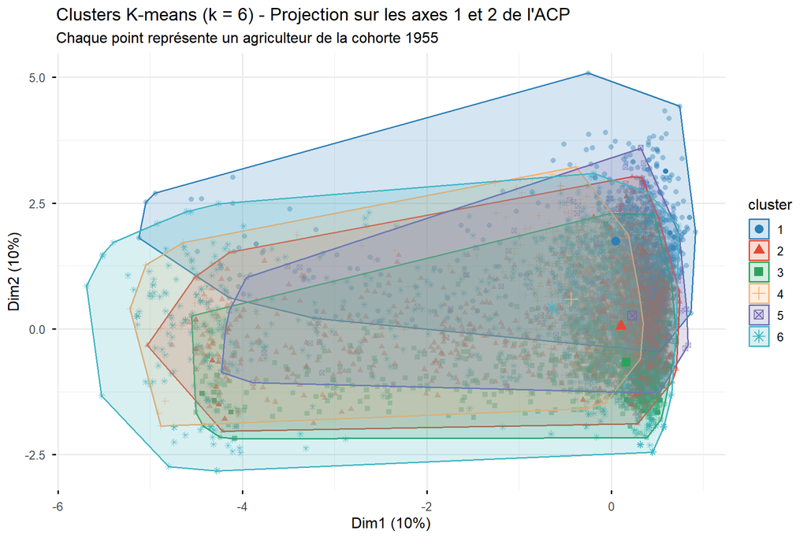

Figure 6 - Projection des clusters sur les axes 1 et 2 de l’ACP

```r
fviz_cluster(list(data = acp_data, cluster = data$cluster),
             geom         = "point",
             ellipse.type = "convex",
             palette      = c("#2c7fb8","#e34a33","#2ca25f","#fdae6b","#756bb1","#41b6c4"),
             alpha        = 0.4,
             ggtheme      = theme_minimal(base_size = 12)) +
  labs(title    = "Clusters K-means (k = 6) - Projection sur les axes 1 et 2 de l'ACP",
       subtitle = "Chaque point représente un agriculteur de la cohorte 1955")
```

> *Cluster 2 (n = 4 633 - 38,82 %) :* Ce cluster dominant regroupe des agriculteurs fortement spécialisés dans l’**élevage bovin** (ratio 0.88) et les **prairies** (0.87), associés à des cultures céréalières importantes - blé/orge (0.63) et maïs (0.44). Les élevages secondaires (moutons, cochons, chevaux, volailles) sont nettement inférieurs à la moyenne. Ces agriculteurs ont démarré tôt (16,89 ans) et ont consacré une longue carrière à l’agriculture (36 ans). Ce profil correspond aux agriculteurs de polyculture-élevage dominant les zones herbagères du Grand Ouest dans les années 1950–1970.

> *Cluster 1 (n = 636 - 5,33 %) :* Ce cluster se démarque nettement par un ratio de **colza exceptionnel (0.76)**, contre 0.05 en population, associé à de très fortes pratiques de blé/orge (0.91), de maïs (0.65) et de prairies (0.70). Il représente des **grands cultivateurs spécialisés dans les oléagineux et céréales**, avec une carrière longue (34,67 ans).

### 3.1.5 Tableau de synthèse - Activités dans les clusters (Partie I)

```r
# Variables de maladies
maladies_vars <- c("M_FoinF","M_EczemaF","M_AsthmeF","M_BronchiteF","M_EmphysemeF",
                   "M_PoumonF","M_InfarctusF","M_CardiaqueF","M_HypertensionF",
                   "M_ThyroideF","M_RetineF","M_DiabeteF","M_DepressionF",
                   "M_ParkinsonF","M_AlzheimerF")

# Ratio activités dans les clusters
ratio_vars <- c("Ratio_Bov","Ratio_Mou","Ratio_Coc","Ratio_Che","Ratio_Vol",
                top10)

top_clusters <- names(sort(table(data$cluster), decreasing = TRUE))[1:4]

tab_act <- data %>%
  filter(cluster %in% as.integer(top_clusters)) %>%
  group_by(cluster) %>%
  summarise(across(all_of(ratio_vars), ~ round(mean(.x, na.rm = TRUE), 2), .names = "{.col}"),
            .groups = "drop")

# Population globale
pop_glob <- data %>%
  summarise(across(all_of(ratio_vars), ~ round(mean(.x, na.rm = TRUE), 2), .names = "{.col}")) %>%
  mutate(cluster = "Population")

tab_act_full <- bind_rows(tab_act %>% mutate(cluster = as.character(cluster)), pop_glob) %>%
  pivot_longer(-cluster, names_to = "Activité", values_to = "Ratio moyen") %>%
  pivot_wider(names_from = cluster, values_from = `Ratio moyen`)

# Réorganisation : élevage puis cultures
tab_act_full <- tab_act_full %>%
  mutate(Type = ifelse(Activité %in% c("Ratio_Bov","Ratio_Mou","Ratio_Coc","Ratio_Che","Ratio_Vol"),
                       "Élevage", "Culture")) %>%
  arrange(Type, Activité) %>%
  mutate(Activité = gsub("Ratio_", "", Activité))

kbl(tab_act_full %>% select(-Type),
    caption = "Tableau 8 - Ratios moyens d'activités (élevage et culture) par cluster",
    align   = c("l", rep("c", ncol(tab_act_full)-2))) %>%
  kable_styling(bootstrap_options = c("striped","hover","condensed"), full_width = TRUE) %>%
  pack_rows("Élevage", 1,  sum(tab_act_full$Type == "Élevage")) %>%
  pack_rows("Culture", sum(tab_act_full$Type == "Élevage") + 1, nrow(tab_act_full))
```

Tableau 8 - Ratios moyens d’activités (élevage et culture) par cluster

[output not shown]

### 3.1.6 Tableau de synthèse - Population des clusters (Partie I)

```r
tab_pop <- data %>%
  filter(cluster %in% as.integer(top_clusters)) %>%
  group_by(cluster) %>%
  summarise(
    `Âge début (moy.)` = round(mean(carriereAgriDeb - A_Nais, na.rm = TRUE), 1),
    `Durée carrière (moy.)` = round(mean(DureeVieProfAgri, na.rm = TRUE), 1),
    `N`                = n(),
    .groups = "drop"
  ) %>%
  mutate(cluster = as.character(cluster))

pop_glob_pop <- data %>%
  summarise(
    `Âge début (moy.)` = round(mean(carriereAgriDeb - A_Nais, na.rm = TRUE), 1),
    `Durée carrière (moy.)` = round(mean(DureeVieProfAgri, na.rm = TRUE), 1),
    `N`                = n()
  ) %>%
  mutate(cluster = "Population")

tab_pop_full <- bind_rows(tab_pop, pop_glob_pop)

kbl(tab_pop_full,
    col.names = c("Cluster","Âge début carrière (ans)","Durée carrière (ans)","Effectif"),
    caption   = "Tableau 9 - Caractéristiques de la population par cluster",
    align     = c("l","c","c","c")) %>%
  kable_styling(bootstrap_options = c("striped","hover","condensed"), full_width = FALSE) %>%
  row_spec(nrow(tab_pop_full), bold = TRUE, background = "#f0f0f0")
```

Tableau 9 - Caractéristiques de la population par cluster

| Cluster | Âge début carrière (ans) | Durée carrière (ans) | Effectif |
| --- | --- | --- | --- |
| 1 | 17.5 | 34.7 | 636 |
| 2 | 16.9 | 35.9 | 4633 |
| 3 | 18.1 | 31.4 | 3842 |
| 6 | 16.5 | 25.0 | 1621 |
| Population | 17.3 | 32.5 | 11934 |

## 3.2 Partie II - Description des clusters

### 3.2.1 Description des 4 plus grands clusters

```r
kbl(tab_act_full %>% select(-Type),
    caption = "Tableau 10 - Ratios moyens d'activités par cluster (avec population globale)",
    align   = c("l", rep("c", ncol(tab_act_full)-2))) %>%
  kable_styling(bootstrap_options = c("striped","hover","condensed"), full_width = TRUE) %>%
  pack_rows("Élevage",  1, sum(tab_act_full$Type == "Élevage")) %>%
  pack_rows("Culture",  sum(tab_act_full$Type == "Élevage") + 1, nrow(tab_act_full))
```

Tableau 10 - Ratios moyens d’activités par cluster (avec population globale)

[output not shown]

**Description détaillée des 4 plus grands clusters :**

**Cluster 2** (n = 4 633 - 38,82 %) - *Céréaliers-éleveurs bovins de plaine*

Ce cluster dominant regroupe des agriculteurs caractérisés par une très forte pratique de l’**élevage bovin** (ratio 0.88, +0.25 vs population) et des **prairies** (0.87, +0.29), combinée à des cultures céréalières - blé/orge (0.63) et maïs (0.44). Les élevages secondaires restent bien en deçà de la moyenne. Ces agriculteurs ont démarré jeunes (16,89 ans) et ont consacré en moyenne 36 ans à l’agriculture. Ce profil est typique des exploitations de polyculture-élevage qui dominaient les zones herbagères normandes et bretonnes dans les années 1950–1970. Sur le plan sanitaire, la **bronchite chronique** (11,73 %) et l’**hypertension artérielle** (33,11 %) sont parmi les pathologies les plus représentées de ce cluster, possiblement en lien avec l’exposition aux aérosols d’étable et aux poussières organiques.

**Cluster 6** (n = 1 621 - 13,58 %) - *Polyéleveurs-polycultures intensifs*

**Cluster 1** (n = 636 - 5,33 %) - *Spécialistes colza-céréales*

Ce cluster, le moins peuplé des quatre analysés, se distingue par un ratio de **colza exceptionnel** (0.76, contre 0.05 en population), associé à de très fortes pratiques de blé/orge (0.91), de maïs (0.65) et de prairies (0.70). Ces grands cultivateurs spécialisés dans les oléagineux et céréales ont démarré leur carrière tardivement (17,46 ans) mais ont exercé longtemps (34,67 ans). Le **rhume des foins** (11,15 %) et l’**eczéma** (7,01 %) y sont les plus fréquents, possiblement en lien avec les allergènes libérés lors des moissons et l’exposition aux herbicides des cultures d’hiver.

### 3.2.2 Tableau de synthèse - Prévalences des maladies par cluster

```r
# Labels lisibles pour les maladies
maladie_labels <- c(
  M_FoinF        = "Rhume des foins",
  M_EczemaF      = "Eczéma",
  M_AsthmeF      = "Asthme",
  M_BronchiteF   = "Bronchite chronique",
  M_EmphysemeF   = "Emphysème",
  M_PoumonF      = "Maladie du poumon de fermier",
  M_InfarctusF   = "Infarctus / Angine de poitrine",
  M_CardiaqueF   = "Troubles du rythme cardiaque",
  M_HypertensionF= "Hypertension artérielle",
  M_ThyroideF    = "Maladie de la thyroïde",
  M_RetineF      = "Maladie de la rétine",
  M_DiabeteF     = "Diabète",
  M_DepressionF  = "Dépression",
  M_ParkinsonF   = "Maladie de Parkinson",
  M_AlzheimerF   = "Maladie d'Alzheimer"
)

avail_maladies <- intersect(maladies_vars, names(data))

tab_mal <- data %>%
  filter(cluster %in% as.integer(top_clusters)) %>%
  group_by(cluster) %>%
  summarise(across(all_of(avail_maladies),
                   ~ round(mean(.x, na.rm = TRUE) * 100, 2)),
            .groups = "drop")

pop_mal <- data %>%
  summarise(across(all_of(avail_maladies),
                   ~ round(mean(.x, na.rm = TRUE) * 100, 2))) %>%
  mutate(cluster = "Population")

tab_mal_full <- bind_rows(
  tab_mal %>% mutate(cluster = as.character(cluster)),
  pop_mal
) %>%
  pivot_longer(-cluster, names_to = "Maladie", values_to = "Prévalence (%)") %>%
  pivot_wider(names_from = cluster, values_from = `Prévalence (%)`) %>%
  mutate(Maladie = maladie_labels[Maladie])

kbl(tab_mal_full,
    caption = "Tableau 11 - Prévalences (%) des maladies par cluster (cohorte 1955)",
    align   = c("l", rep("c", ncol(tab_mal_full)-1))) %>%
  kable_styling(bootstrap_options = c("striped","hover","condensed"), full_width = TRUE)
```

Tableau 11 - Prévalences (%) des maladies par cluster (cohorte 1955)

| Maladie | 1 | 2 | 3 | 6 | Population |
| --- | --- | --- | --- | --- | --- |
| Rhume des foins | 11.15 | 8.49 | 9.05 | 11.06 | 9.28 |
| Eczéma | 7.01 | 5.14 | 5.93 | 6.57 | 5.67 |
| Asthme | 6.20 | 6.94 | 7.18 | 6.97 | 7.18 |
| Bronchite chronique | 9.76 | 11.73 | 11.56 | 15.77 | 12.13 |
| Emphysème | 2.25 | 1.38 | 1.63 | 2.23 | 1.70 |
| Maladie du poumon de fermier | 2.24 | 1.90 | 1.02 | 2.13 | 1.69 |
| Infarctus / Angine de poitrine | 7.93 | 8.73 | 10.57 | 12.42 | 9.75 |
| Troubles du rythme cardiaque | 17.50 | 16.39 | 18.04 | 19.85 | 17.52 |
| Hypertension artérielle | 38.34 | 33.11 | 36.51 | 38.80 | 35.62 |
| Maladie de la thyroïde | 1.89 | 2.55 | 3.11 | 3.59 | 2.83 |
| Maladie de la rétine | 1.90 | 2.43 | 3.41 | 3.94 | 3.02 |
| Diabète | 11.17 | 8.02 | 12.60 | 10.91 | 10.36 |
| Dépression | 7.57 | 4.97 | 5.98 | 7.44 | 5.96 |
| Maladie de Parkinson | 1.20 | 1.01 | 1.41 | 1.17 | 1.17 |
| Maladie d’Alzheimer | 0.52 | 0.15 | 0.71 | 0.55 | 0.43 |

### 3.2.3 Distributions de probabilités - Activités principales

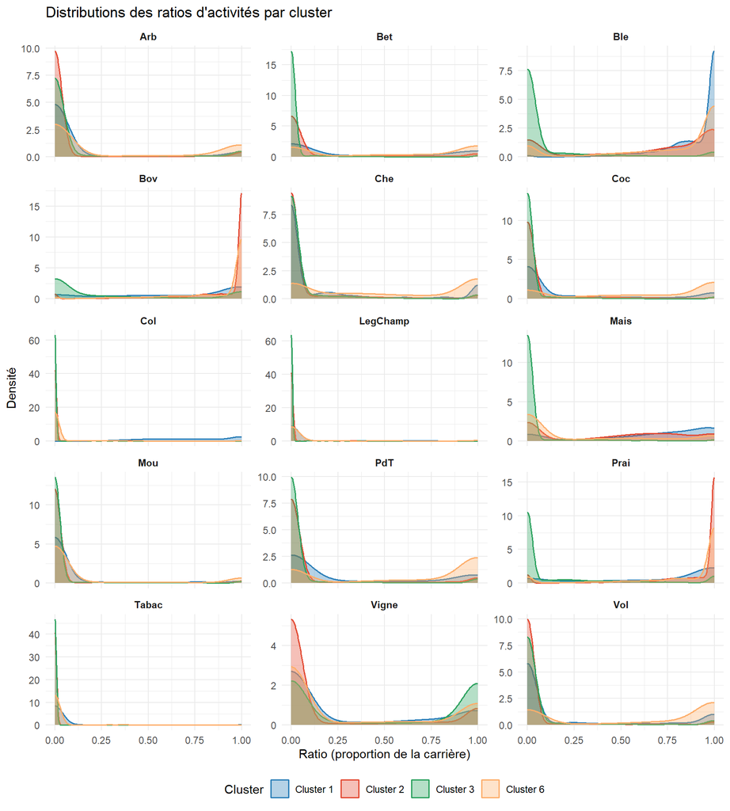

Figure 7 - Distributions des ratios d’activités selon les clusters

```r
data_long <- data %>%
  filter(cluster %in% as.integer(top_clusters)) %>%
  select(cluster, all_of(ratio_vars)) %>%
  pivot_longer(-cluster, names_to = "Activité", values_to = "Ratio") %>%
  mutate(
    Activité = gsub("Ratio_", "", Activité),
    cluster  = paste0("Cluster ", cluster)
  )

ggplot(data_long, aes(x = Ratio, fill = cluster, color = cluster)) +
  geom_density(alpha = 0.35, linewidth = 0.6) +
  facet_wrap(~ Activité, scales = "free_y", ncol = 3) +
  scale_fill_manual(values  = c("#2c7fb8","#e34a33","#2ca25f","#fdae6b")) +
  scale_color_manual(values = c("#2c7fb8","#e34a33","#2ca25f","#fdae6b")) +
  labs(title  = "Distributions des ratios d'activités par cluster",
       x      = "Ratio (proportion de la carrière)",
       y      = "Densité",
       fill   = "Cluster",
       color  = "Cluster") +
  theme_minimal(base_size = 11) +
  theme(legend.position = "bottom",
        strip.text      = element_text(face = "bold"))
```

# 4 Conclusion

Cette analyse a permis de caractériser les **profils agricoles** de 11 934 hommes de la cohorte 1955 ayant débuté leur carrière entre 1945 et 1965, à partir de 15 ratios d’activités reconstitués sur l’ensemble de leur parcours professionnel.

L’ACP a mis en évidence une structure multidimensionnelle des pratiques agricoles, nécessitant **10 composantes principales** pour expliquer 84,51 % de la variance totale. Les quatre premiers axes structurent les données selon un gradient de polyvalence agricole (axe 1), une opposition maïs-élevage bovin *versus* pomme de terre (axe 2), une spécialisation vers les cultures de rente comme le colza et le tabac (axe 3), et une opposition viticulture *versus* maraîchage (axe 4).

Parmi les cinq méthodes de clustering testées, le **K-means avec k = 6** s’est révélé le plus performant (silhouette = 0.2373). Le DBSCAN, inadapté à la structure des données (58 micro-clusters, 22,7 % de bruit), a obtenu une silhouette négative. Les 6 clusters identifiés reflètent la diversité des pratiques agricoles de cette génération. Les quatre clusters les plus peuplés se distinguent nettement :

Ces résultats appellent à des analyses étiologiques complémentaires pour tester statistiquement les associations entre profils agricoles et risques de maladies, en ajustant sur les facteurs de confusion (tabagisme, âge, pesticides spécifiques utilisés). La nature déclarative des données et les biais de mémorisation constituent les principales limites de cette étude.

# 5 Publications

- **[1]** Omland Ø. Exposure and respiratory health in farming in temperate zones - a review of the literature. *Ann Agric Environ Med.* 2002 ; 9(2) : 119–136.
- **[2]** Blair A, Sandler DP, Tarone R, *et al.* Mortality among participants in the agricultural health study. *Ann Epidemiol.* 2005 ; 15(4) : 279–285.
- **[3]** Hernandez AF, Parron T, Tsatsakis AM, *et al.* Toxic effects of pesticide mixtures at a molecular level: their relevance to human health. *Toxicology.* 2013 ; 307 : 136–145.
- **[4]** Leon ME, Beane Freeman LE, Douwes J, *et al.* AGRICOH: a consortium of agricultural cohort studies. *J Occup Environ Med.* 2011 ; 53(11) : 1337–1344.

*Rapport généré le 04 avril 2026 - IUT Grand Ouest Normandie, antenne de Lisieux - BUT Science des Données*